# Treatment Efficacy Analysis of a Randomised Trial

Does rectal indomethacin prevent post-ERCP pancreatitis? Effect size, NNT and subgroups

Kingsley Amegah

June 2026

# 1 Background and question

A randomised controlled trial can do more than show that a treatment works. It can quantify **how much** it helps, in terms a clinician and a patient can act on: the absolute risk reduction, the relative risk, and the **number needed to treat (NNT)**, the number of patients you must treat to prevent one event.

This report analyses a real, published placebo-controlled trial (Elmunzer and colleagues, *New England Journal of Medicine*, 2012). **602 patients** at high risk of complications from ERCP (a procedure on the bile and pancreatic ducts) were randomised to a single dose of **rectal indomethacin** or **placebo**. The primary endpoint was **post-ERCP pancreatitis (PEP)**, a painful and sometimes serious inflammation of the pancreas.

# 2 Baseline balance

Randomisation should make the two groups comparable before treatment. We check this first.

```r
bt <- dat |>
  select(rx, age, gender, risk, risk_group, prior_pep, sod, psphinc, difcan, train) |>
  tbl_summary(
    by    = rx,
    type  = list(gender ~ "dichotomous", risk_group ~ "dichotomous"),
    value = list(gender ~ "Male", risk_group ~ "Higher risk (>2.5)"),
    label = list(age ~ "Age, years", gender ~ "Male sex",
                 risk ~ "Risk score", risk_group ~ "Higher risk (score >2.5)",
                 prior_pep ~ "Prior pancreatitis", sod ~ "Sphincter of Oddi dysfunction",
                 psphinc ~ "Pancreatic sphincterotomy", difcan ~ "Difficult cannulation",
                 train ~ "Trainee involved"),
    digits = all_categorical() ~ c(0, 1)) |>
  add_p(pvalue_fun = ~ style_pvalue(.x, digits = 3)) |>
  modify_header(label ~ "**Characteristic**") |>
  modify_caption("**Table 1. Baseline characteristics by treatment arm**")
cat(strip_dash(as_kable(bt)), sep = "\n")
```

**Table 1. Baseline characteristics by treatment arm**

| **Characteristic** | **Placebo** N = 307 | **Indomethacin** N = 295 | **p-value** |
| --- | --- | --- | --- |
| Age, years | 46 (36, 55) | 44 (33, 54) | 0.184 |
| Male sex | 60 (19.5%) | 66 (22.4%) | 0.394 |
| Risk score | 2.50 (1.50, 3.00) | 2.50 (2.00, 3.00) | 0.315 |
| Higher risk (score >2.5) | 85 (27.7%) | 87 (29.5%) | 0.624 |
| Prior pancreatitis | 49 (16.0%) | 47 (15.9%) | 0.992 |
| Sphincter of Oddi dysfunction | 247 (80.5%) | 248 (84.1%) | 0.247 |
| Pancreatic sphincterotomy | 170 (55.4%) | 173 (58.6%) | 0.418 |
| Difficult cannulation | 77 (25.1%) | 80 (27.1%) | 0.569 |
| Trainee involved | 140 (45.6%) | 143 (48.5%) | 0.480 |

The arms were well matched on age, sex, risk score and every procedural risk factor (all p-values large), confirming that randomisation produced comparable groups. Any difference in pancreatitis can therefore be attributed to the treatment.

# 3 Primary efficacy: how big is the benefit?

```r
tab <- table(dat$rx, dat$pep)              # rows: Placebo, Indomethacin
a <- tab["Indomethacin", "Yes"]; b <- tab["Indomethacin", "No"]
c <- tab["Placebo", "Yes"];      d <- tab["Placebo", "No"]
e <- eff(a, b, c, d)
chip <- chisq.test(tab)$p.value
res <- tibble::tibble(
  Measure = c("PEP, placebo", "PEP, indomethacin",
              "Absolute risk reduction (ARR)", "Relative risk (RR)",
              "Relative risk reduction", "Odds ratio (OR)",
              "Number needed to treat (NNT)"),
  Value = c(sprintf("%.1f%%", e$p0 * 100),
            sprintf("%.1f%%", e$p1 * 100),
            sprintf("%.1f pp (95%% CI %.1f to %.1f)", e$arr*100, e$arr_l*100, e$arr_u*100),
            sprintf("%.2f (95%% CI %.2f to %.2f)", e$rr, e$rr_l, e$rr_u),
            sprintf("%.0f%%", (1 - e$rr) * 100),
            sprintf("%.2f (95%% CI %.2f to %.2f)", e$or, e$or_l, e$or_u),
            sprintf("%.0f (95%% CI %.0f to %.0f)", e$nnt, e$nnt_l, e$nnt_u)))
knitr::kable(res, caption = "Primary endpoint: effect of indomethacin vs placebo")
```

Primary endpoint: effect of indomethacin vs placebo

| Measure | Value |
| --- | --- |
| PEP, placebo | 16.9% |
| PEP, indomethacin | 9.2% |
| Absolute risk reduction (ARR) | 7.8 pp (95% CI 2.5 to 13.1) |
| Relative risk (RR) | 0.54 (95% CI 0.35 to 0.84) |
| Relative risk reduction | 46% |
| Odds ratio (OR) | 0.49 (95% CI 0.30 to 0.81) |
| Number needed to treat (NNT) | 13 (95% CI 8 to 41) |

```r
cat(sprintf("\nChi-square p-value: %.4f\n", chip))
```

```
##
## Chi-square p-value: 0.0068
```

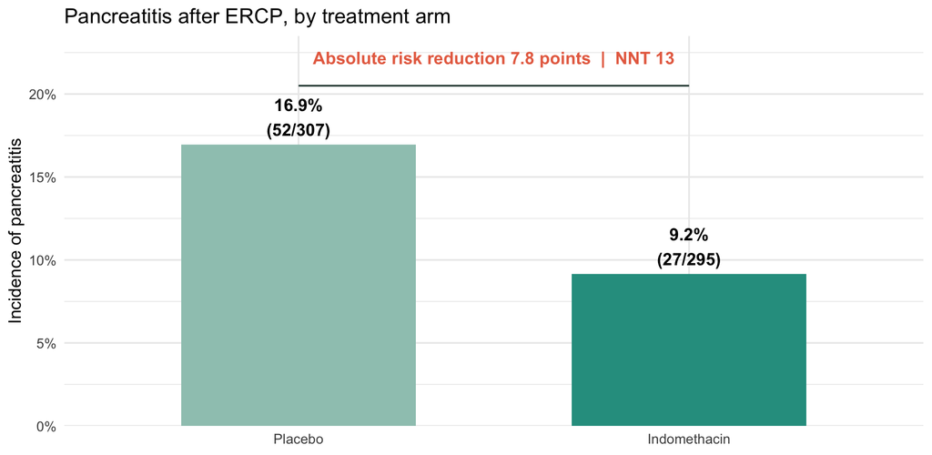

```r
pd <- dat |> group_by(rx) |>
  summarise(rate = mean(pep_event), n = n(), ev = sum(pep_event), .groups = "drop")
ggplot(pd, aes(rx, rate, fill = rx)) +
  geom_col(width = 0.6) +
  geom_text(aes(label = sprintf("%.1f%%\n(%d/%d)", rate*100, ev, n)),
            vjust = -0.25, fontface = "bold", size = 4.2) +
  scale_fill_manual(values = PAL, guide = "none") +
  scale_y_continuous(labels = percent, limits = c(0, 0.235), expand = c(0, 0)) +
  annotate("segment", x = 1, xend = 2, y = 0.205, yend = 0.205, colour = INK) +
  annotate("text", x = 1.5, y = 0.222,
           label = sprintf("Absolute risk reduction %.1f points  |  NNT %.0f",
                           e$arr*100, e$nnt), fontface = "bold", colour = CORAL) +
  labs(title = "Pancreatitis after ERCP, by treatment arm",
       x = NULL, y = "Incidence of pancreatitis")
```

Indomethacin roughly **halved** the incidence of pancreatitis, from 16.9% on placebo to 9.2%. The absolute risk reduction of 7.8 percentage points translates into a **number needed to treat of about 13**: treat roughly 13 high-risk patients with one cheap suppository to prevent one case of pancreatitis. That is an unusually efficient preventive effect.

# 4 Adjusted analysis

Randomisation already balances the arms, but adjusting for baseline risk factors gives a more precise estimate and shows the effect holds independent of them.

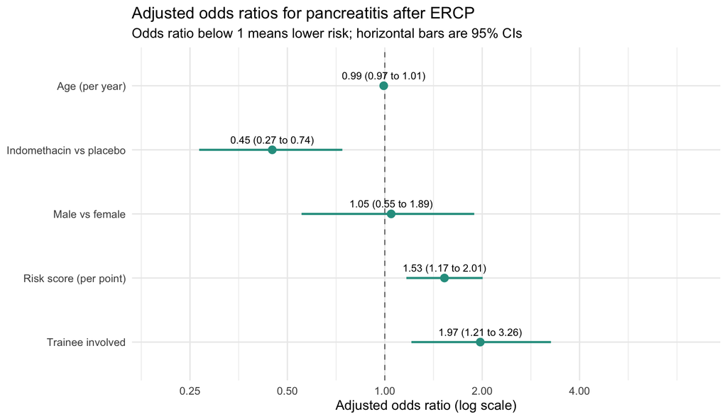

```r
fit <- glm(pep_event ~ rx + risk + age + gender + train,
           family = binomial, data = dat)
adj <- tidy(fit, exponentiate = TRUE, conf.int = TRUE) |>
  filter(term != "(Intercept)") |>
  mutate(label = recode(term,
    rxIndomethacin = "Indomethacin vs placebo", risk = "Risk score (per point)",
    age = "Age (per year)", genderMale = "Male vs female",
    trainYes = "Trainee involved"))
ggplot(adj, aes(estimate, fct_rev(label))) +
  geom_vline(xintercept = 1, linetype = "dashed", colour = "grey50") +
  geom_pointrange(aes(xmin = conf.low, xmax = conf.high), colour = ACC, linewidth = 0.9) +
  geom_text(aes(label = sprintf("%.2f (%.2f to %.2f)", estimate, conf.low, conf.high)),
            vjust = -0.9, size = 3.2) +
  scale_x_log10(limits = c(0.2, 9), breaks = c(0.25, 0.5, 1, 2, 4)) +
  labs(title = "Adjusted odds ratios for pancreatitis after ERCP",
       subtitle = "Odds ratio below 1 means lower risk; horizontal bars are 95% CIs",
       x = "Adjusted odds ratio (log scale)", y = NULL)
```

```r
aor <- adj |> filter(term == "rxIndomethacin")
cat(sprintf("Adjusted OR for indomethacin: %.2f (95%% CI %.2f to %.2f), p = %.4f\n",
            aor$estimate, aor$conf.low, aor$conf.high, aor$p.value))
```

```
## Adjusted OR for indomethacin: 0.45 (95% CI 0.27 to 0.74), p = 0.0020
```

After adjusting for the composite risk score, age, sex and trainee involvement, indomethacin remained associated with roughly **half the odds** of pancreatitis, and the effect was statistically significant. The composite risk score was, as expected, a strong independent predictor of the outcome.

# 5 Subgroup analysis: who benefits?

A key clinical question is whether the benefit is consistent across patient types, or concentrated in some. We estimate the relative risk within each subgroup and test for an interaction (effect modification).

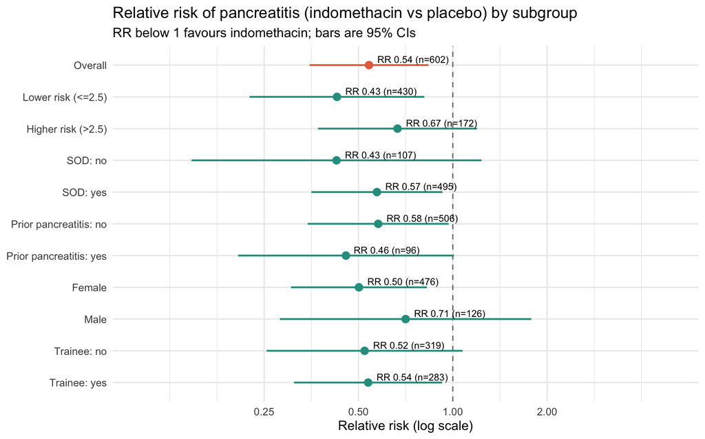

```r
subs <- list(
  "Overall" = rep(TRUE, nrow(dat)),
  "Lower risk (<=2.5)"  = dat$risk_group == "Lower risk (<=2.5)",
  "Higher risk (>2.5)"  = dat$risk_group == "Higher risk (>2.5)",
  "SOD: no"  = dat$sod == "No",   "SOD: yes" = dat$sod == "Yes",
  "Prior pancreatitis: no"  = dat$prior_pep == "No",
  "Prior pancreatitis: yes" = dat$prior_pep == "Yes",
  "Female" = dat$gender == "Female", "Male" = dat$gender == "Male",
  "Trainee: no" = dat$train == "No", "Trainee: yes" = dat$train == "Yes")

rows <- lapply(names(subs), function(nm) {
  s <- dat[subs[[nm]], ]
  t <- table(factor(s$rx, levels = c("Placebo","Indomethacin")), s$pep)
  if (any(t[, "Yes"] == 0)) return(NULL)
  ee <- eff(t["Indomethacin","Yes"], t["Indomethacin","No"],
            t["Placebo","Yes"], t["Placebo","No"])
  data.frame(group = nm, rr = ee$rr, lo = ee$rr_l, hi = ee$rr_u,
             n = nrow(s))
})
sub_df <- do.call(rbind, rows)
sub_df$group <- factor(sub_df$group, levels = rev(sub_df$group))

ggplot(sub_df, aes(rr, group)) +
  geom_vline(xintercept = 1, linetype = "dashed", colour = "grey50") +
  geom_pointrange(aes(xmin = lo, xmax = hi),
                  colour = ifelse(sub_df$group == "Overall", CORAL, ACC),
                  linewidth = 0.8) +
  geom_text(aes(label = sprintf("RR %.2f (n=%d)", rr, n)), hjust = -0.12,
            size = 3.1, nudge_y = 0.18) +
  scale_x_log10(limits = c(0.1, 5), breaks = c(0.25, 0.5, 1, 2)) +
  labs(title = "Relative risk of pancreatitis (indomethacin vs placebo) by subgroup",
       subtitle = "RR below 1 favours indomethacin; bars are 95% CIs",
       x = "Relative risk (log scale)", y = NULL)
```

```r
p_risk  <- anova(glm(pep_event ~ rx * risk_group, binomial, dat), test = "LRT")$`Pr(>Chi)`[4]
p_sod   <- anova(glm(pep_event ~ rx * sod, binomial, dat), test = "LRT")$`Pr(>Chi)`[4]
p_prior <- anova(glm(pep_event ~ rx * prior_pep, binomial, dat), test = "LRT")$`Pr(>Chi)`[4]
cat(sprintf("Interaction p-values:  risk group = %.2f | SOD = %.2f | prior pancreatitis = %.2f\n",
            p_risk, p_sod, p_prior))
```

```
## Interaction p-values:  risk group = 0.42 | SOD = 0.60 | prior pancreatitis = 0.49
```

The point estimates favour indomethacin in essentially every subgroup, and no interaction test is significant (all p > 0.05). In plain terms, the benefit is **consistent across patient types**: there is no good evidence that any group fails to benefit, so the treatment can be applied broadly to high-risk patients rather than restricted to a subset.

# 6 Results

This section states the findings in the style of a clinical journal.

Among 602 patients at high risk for post-ERCP pancreatitis randomised to rectal indomethacin or placebo, the arms were well balanced at baseline (Table 1). Post-ERCP pancreatitis occurred in 27 of 295 (9.2%) patients given indomethacin, compared with 52 of 307 (16.9%) given placebo (relative risk 0.54; 95% CI, 0.35 to 0.84; P = 0.007). This corresponds to an absolute risk reduction of 7.8 percentage points and a number needed to treat of 13 (95% CI, 8 to 41). The effect persisted after adjustment for the composite risk score, age, sex and trainee involvement (adjusted odds ratio 0.45; 95% CI, 0.27 to 0.74; P = 0.002). The treatment effect was consistent across pre-specified subgroups, with no significant interaction by risk group, sphincter of Oddi dysfunction or history of prior pancreatitis.

# 7 Conclusions and clinical implications

In this randomised, placebo-controlled trial, a single dose of rectal indomethacin approximately halved the risk of post-ERCP pancreatitis in high-risk patients, with a number needed to treat of about 13. The benefit was large, statistically robust, adjusted-analysis stable and uniform across subgroups. Given that the intervention is inexpensive, single-dose and widely available, these results support routine prophylactic rectal indomethacin for patients at high risk of this complication.

# 8 Limitations

The trial enrolled patients at elevated risk of pancreatitis, so the absolute benefit and NNT apply to that population and would be smaller in average-risk patients. The bleeding safety endpoint was too sparsely recorded in this dataset to analyse, so this report addresses efficacy only. Subgroup analyses have limited power and are exploratory. As with any single trial, confirmation in other settings strengthens the case, which subsequent studies of this intervention have provided.

*Built in R (dplyr, gtsummary, broom, ggplot2) from the `indo_rct` dataset in the medicaldata package, a real published randomised controlled trial. Author: Kingsley Amegah.*